# Homework 5

Arun Mahadevan Sathia Narayanan

Date Published: 2024-10-23

# Question 1

**Using https://www.basketball-reference.com/wnba/years/2024_totals.html, scrape (either manually, exporting into csv or with using rvest) the player stats from the 2024 season. Create a dataframe containing: the names of the players, the minutes played, and their three-point shooting percentage. How many players are in the roster for 2024?**

```
##             Player Mins Played 3-Point Shooting %
## 1    Lindsay Allen         950              0.292
## 2    Rebecca Allen         447              0.352
## 3 Laeticia Amihere          83                 NA
```

```
##                 Player Mins Played 3-Point Shooting %
## 181   Monique Billings         235              0.286
## 182      Marina Mabrey         439              0.424
## 183 Myisha Hines-Allen         230              0.364
```

The number of players in the roster for 2024 are **183**.

# Question 2

**Create a graph of the distribution of the three-point shooting percentage made by each players. Report and interpret appropriate statistics.**  
To approach this, I first had to get rid of the NA values. I didn’t do this for Question 1 as we still have to count the NA players.

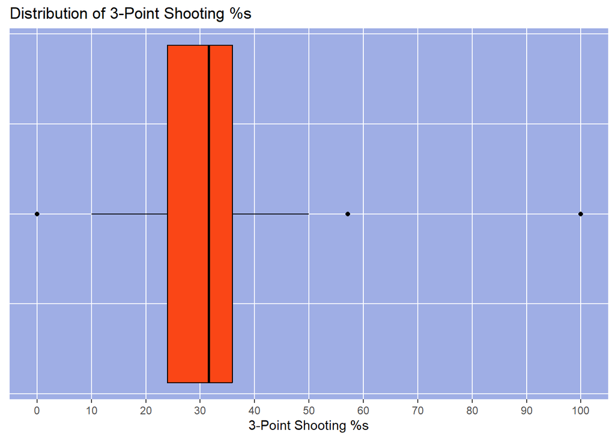

Taking a look at the graph, here are the statistics:

```
##    Min. 1st Qu.  Median    Mean 3rd Qu.    Max.
##    0.00   23.95   31.55   29.71   35.98  100.00
```

Observing both the graph and the table, we can easily tell that most of the 3-Point Shooting Percentages are below the 40% mark. Anything above the 50% in the graph is considered an outlier (my condolences to the 13 players who had a 0% 3-Point Shooting Percentage). The median being 31.55% tells us that almost a third of the 3-Point attempts made by players who had a 3-Point Shooting Percentage made it into the hoop. With the third quartile being around the same value (35.98%), we know that 75% of the players score 3-Pointers less than a little over 1/3 of the time.

# Question 3

**Create a graph that shows the relationship between the minutes played by each player and their three-point shooting percentage. Choose one particular player, highlight her point on the graph and label it with her name.**

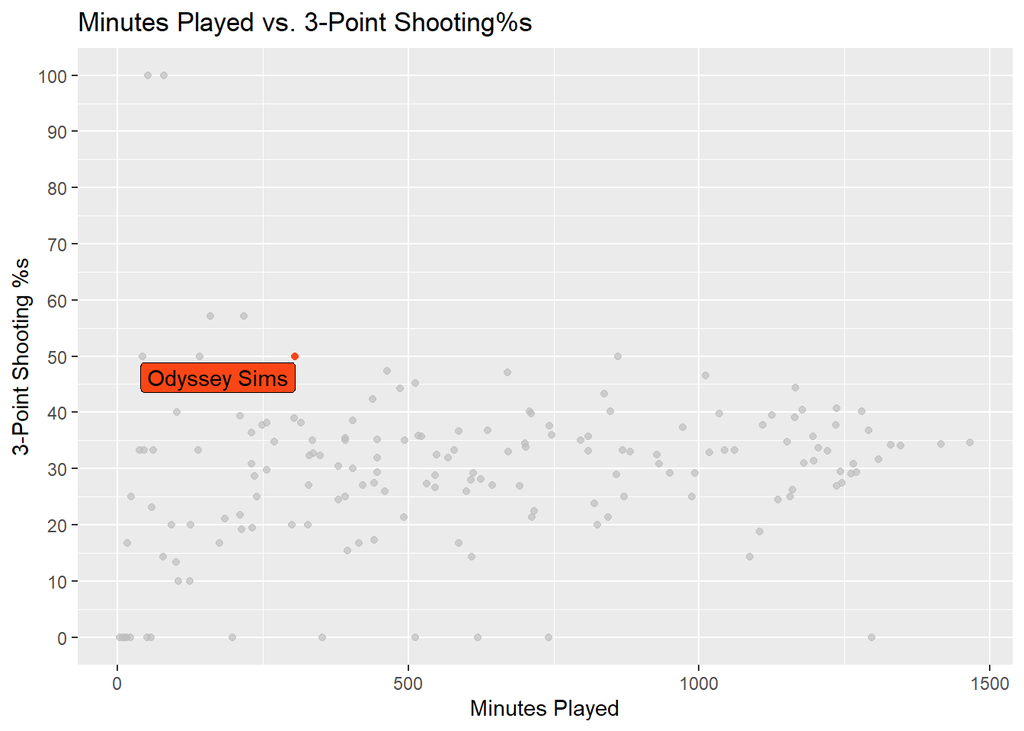

Most of the data seems to be horizontal, underneath the 60% mark. What is the relationship between them then? Initial thoughts would be that the longer a player has been in the court, the more 3-Pointers they would have made. To verify this, let’s perform the calculation.  
The relationship between the two variables is 0.14, which indicates a Weak Positive Correlation. This means that the two variables don’t really affect each others’ outcomes.